# StockResearch

Gabriel Foix

2020-12-05

Buy Quality at the a good momentum and get rid of the fishy stocks on time. That's all.

### Factor 1: Quality

1. Healthy debts: A company shoud generate cash in order to repay its debt. The **Free Cash Flow to Debt** ratio is a good indicator of how quick a company pays back its debt. The lower this ratio the better.

FCF2D = $\frac{Debt}{Free Cash Flow}$

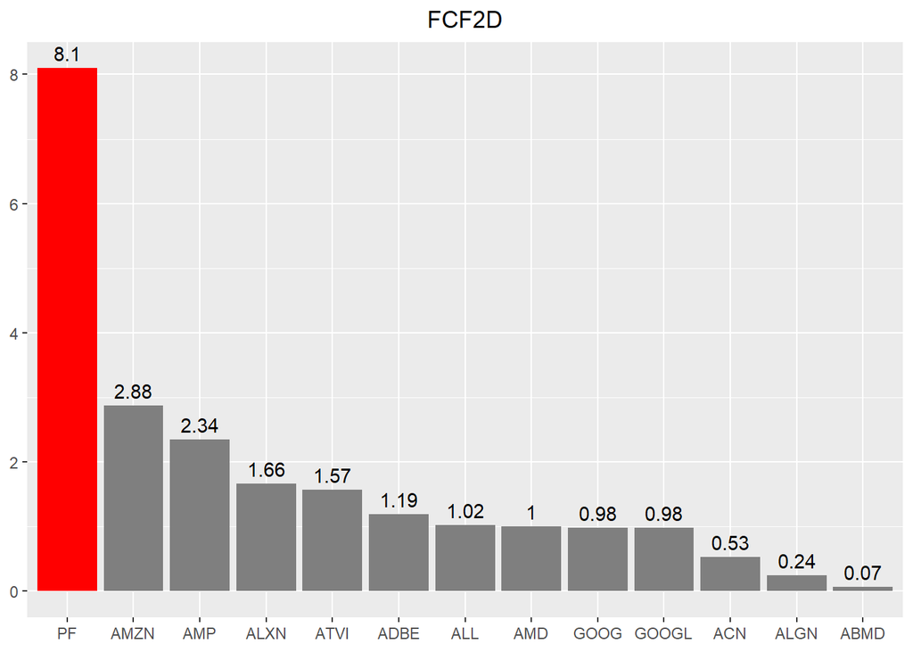

2. Profitability: ROA

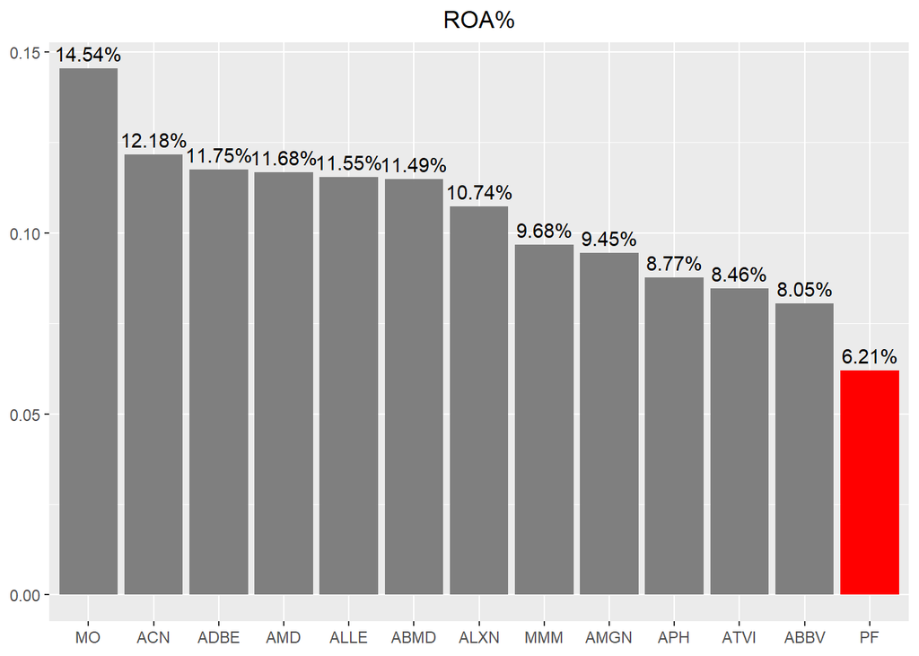

3. High Margin: We look for companies that generate free cash flow compare to its price. The **Free Cash Flow to Entreprise Value** ratio tells us how many years of cash flow would be needed to the return the 100% of the investment. Again, the lower, the better. Values bellow 1 would mean "free lunch".

FCF2EV = $\frac{EV}{Free Cash Flow}$

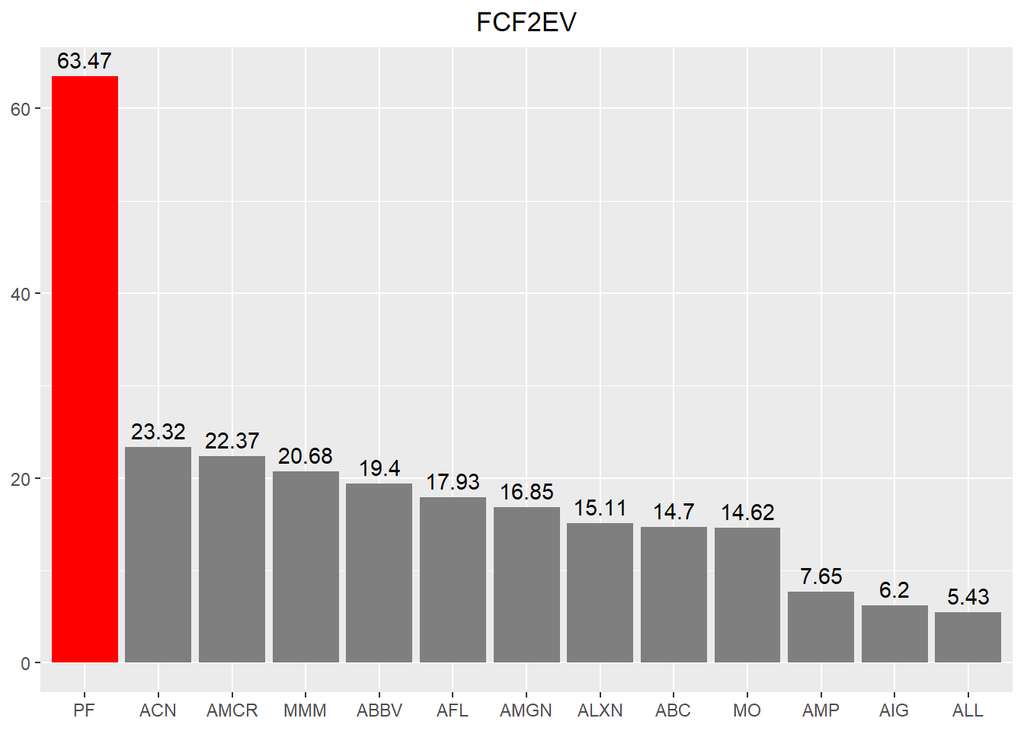

### Factor 2: Momentum

Don't hold onto a stock simply because it is high quality. So called quality stocks have cycles too. Stan Weinstein (page 177)

Generic Intermediate-Term Momentum Based on Gray-Vogel (page 80)

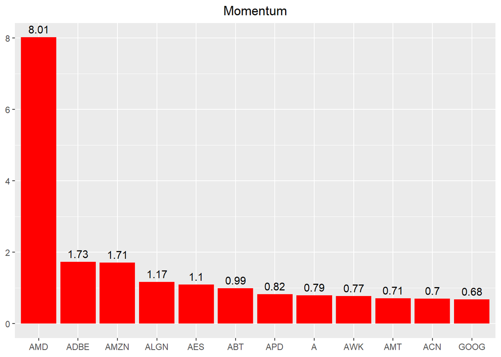

### Factor 3: Timing Signal

Sell Signal - Pr < 1% SMA 30 weeks and slope negative (< -0.2)  
Buy Signal - 109% * SMA30 < Pr > SMA 30 and slope positive (> 0.2)  
Hold Signal - Neither Buy nor Sell

### Summary

```
## Called from: eval(expr, envir, enclos)
```

Summary

| Ticker | Signal | Quality | Momentum | Final_rank |
| --- | --- | --- | --- | --- |
| AWK | HOLD | 38.0 | 32 | 40.0 |
| ACN | HOLD | 39.5 | 30 | 39.0 |
| ADBE | BUY | 24.0 | 39 | 38.0 |
| AMD | HOLD | 20.0 | 40 | 37.0 |
| AEE | HOLD | 36.0 | 20 | 36.0 |
| ALGN | HOLD | 15.5 | 37 | 35.0 |
| LNT | HOLD | 35.0 | 17 | 34.0 |
| GOOG | HOLD | 22.0 | 29 | 33.0 |
| GOOGL | HOLD | 23.0 | 27 | 31.5 |
| AMZN | HOLD | 12.0 | 38 | 31.5 |
| ALB | HOLD | 39.5 | 10 | 30.0 |
| AEP | HOLD | 33.5 | 15 | 29.0 |
| ABMD | HOLD | 26.5 | 21 | 27.5 |
| AMGN | HOLD | 28.5 | 19 | 27.5 |
| AME | HOLD | 19.0 | 28 | 26.0 |
| AXP | HOLD | 32.0 | 13 | 25.0 |
| ATVI | HOLD | 28.5 | 16 | 24.0 |
| ABT | BUY | 9.0 | 35 | 23.0 |
| ALXN | BUY | 37.0 | 6 | 21.5 |
| ALLE | BUY | 21.0 | 22 | 21.5 |
| APH | HOLD | 15.5 | 24 | 20.0 |
| ADI | HOLD | 13.0 | 26 | 19.0 |
| A | HOLD | 5.0 | 33 | 18.0 |
| AMT | SELL | 6.5 | 31 | 17.0 |
| AES | HOLD | 1.0 | 36 | 15.5 |
| APD | HOLD | 3.0 | 34 | 15.5 |
| MO | HOLD | 33.5 | 2 | 14.0 |
| ALK | HOLD | 30.5 | 4 | 13.0 |
| ABBV | HOLD | 18.0 | 14 | 11.5 |
| ALL | HOLD | 25.0 | 7 | 11.5 |
| MMM | BUY | 26.5 | 5 | 9.0 |
| AKAM | HOLD | 6.5 | 25 | 9.0 |
| AAL | HOLD | 30.5 | 1 | 9.0 |
| ABC | HOLD | 17.0 | 12 | 7.0 |
| AAP | HOLD | 4.0 | 23 | 6.0 |
| AMP | HOLD | 14.0 | 11 | 5.0 |
| ARE | BUY | 2.0 | 18 | 3.5 |
| AMCR | BUY | 11.0 | 9 | 3.5 |
| AFL | HOLD | 8.0 | 8 | 2.0 |
| AIG | HOLD | 10.0 | 3 | 1.0 |

Save output in template